# Introduction to data visualization with ggplot

Jeff Oliver

18 July, 2023

An introduction to using the `ggplot` package in R to produce publication-quality graphics.

#### Learning objectives

1. Install and use third-party packages for R
2. Use layering to add elements to a plot
3. Format plots with faceting

## Setup

### Workspace organization

First we need to setup our development environment. Open RStudio and create a new project via:

- File > New Project…
- Select ‘New Directory’
- For the Project Type select ‘New Project’
- For Directory name, call it something like “r-graphing” (without the quotes)
- For the subdirectory, select somewhere you will remember (like “My Documents” or “Desktop”)

We need to create two folders: ‘data’ will store the data we will be analyzing, and ‘output’ will store the results of our analyses.

```r
dir.create(path = "data")
dir.create(path = "output")
```

With this workspace organization, we can download the data, either manually or use R to automatically download it. For this lesson we’ll do the latter, saving the file in the `data` directory we just created, and name the file `gapminder.csv`:

```r
download.file(url = "http://tinyurl.com/gapminder-five-year-csv",
              destfile = "data/gapminder.csv")
```

From this point on, we want to keep track of what we have done, so we will restrict our use of the console and instead use script files. Start a new script with some brief header information at the very top. We want, at the very least, to include:

1. A short description of what the script does (no more than one line of text)
2. Your name
3. A means of contacting you (e.g. your e-mail address)
4. The date, preferably in ISO format YYYY-MM-DD

```r
# Plot gapminder data
# Jeff Oliver
# jcoliver@email.arizona.edu
# 2017-02-23
```

### Installing additional packages

There are two steps to using additional packages in R:

1. Install the package through `install.packages()`
2. Load the package into active memory with `library()`

For this exercise, we will install the `ggplot2` package:

```r
install.packages("ggplot2")
library("ggplot2")
```

It is important to note that for each computer you work on, the `install.packages` command need only be issued once, while the call to `library` will need to be issued for each session of R. Because of this, it is standard convention in scripts to comment out the `install.packages` command once it has been run on the machine, so our script now looks like:

```r
# Plot gapminder data
# Jeff Oliver
# jcoliver@email.arizona.edu
# 2017-02-23

#install.packages("ggplot2")
library("ggplot2")
```

## Now plot!

### Scatterplot

For our first plot, we will create an X-Y scatterplot to investigate a potential relationship between a country’s gross domestic product (GDP) and the average life expectancy. We ultimately want a plot that looks like:

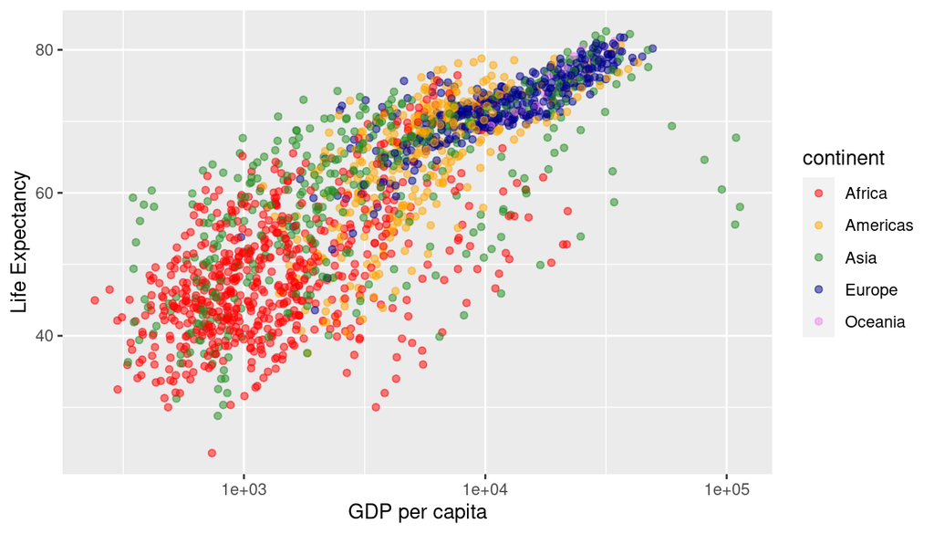

We do so by first reading in the data we downloaded, then creating a `ggplot` object, and finally calling `print` on that object:

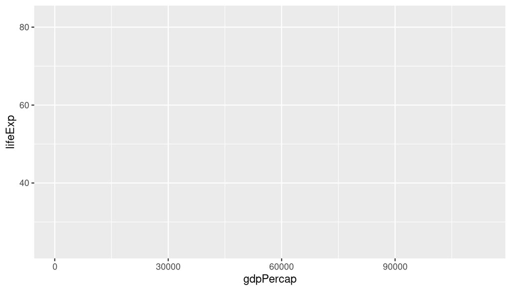

```r
# Load data
gapminder <- read.csv(file = "data/gapminder.csv",
                      stringsAsFactors = TRUE)

# Create plot object
lifeExp_plot <- ggplot(data = gapminder,
                       mapping = aes(x = gdpPercap, y = lifeExp))

# Draw plot
print(lifeExp_plot)
```

*What happened?* There are no points!? Here is where functionality of ggplot is evident. The way it works is by effectively drawing layer upon layer of graphics. So we have established the plot, but we need to add one more bit of information to tell ggplot what to put in that plot area. For a scatter plot, we use `geom_point()`, literally adding this to the ggplot object with a plus sign (+):

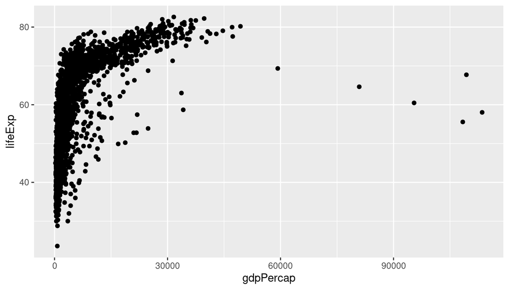

```r
# Create plot object
lifeExp_plot <- ggplot(data = gapminder,
                       mapping = aes(x = gdpPercap, y = lifeExp)) +
  geom_point()

# Draw plot
print(lifeExp_plot)
```

It is a little difficult to see how the points are distributed, as most are clustered on the left-hand side of the graph. To spread this distribution out, we can change the scale of the x-axis so GDP is displayed on a log scale by adding `scale_x_log10`:

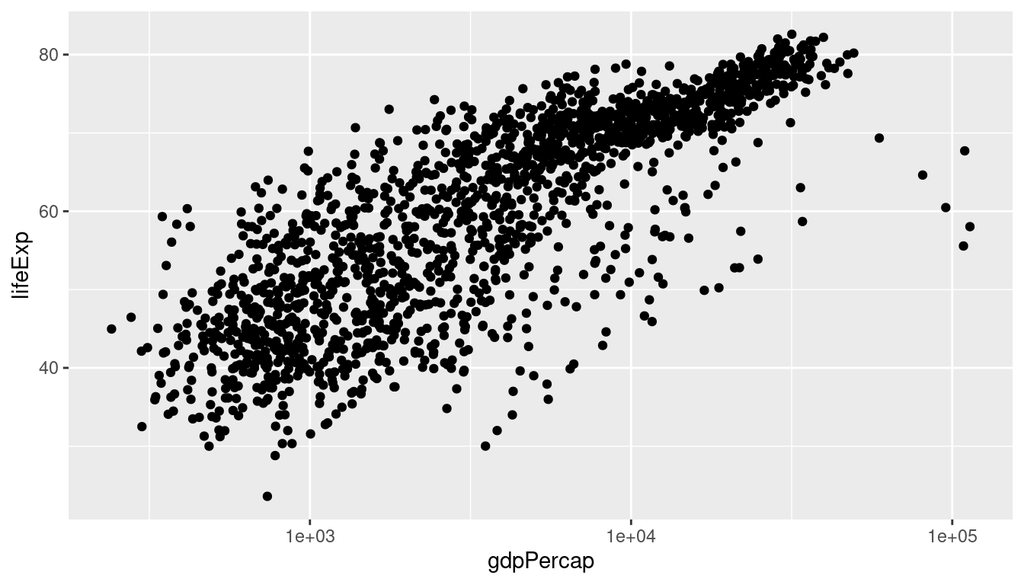

```r
# Create plot object
lifeExp_plot <- ggplot(data = gapminder,
                       mapping = aes(x = gdpPercap, y = lifeExp)) +
  geom_point() +
  scale_x_log10()

# Draw plot
print(lifeExp_plot)
```

One thing of interest is to include additional information in the plot, such as which continent each point comes from. We can color points by another value in our data through the `aes` parameter in the initial call to `ggplot`. So in addition to telling R which data to use for the x and y axes, we indicate which data to use for point colors:

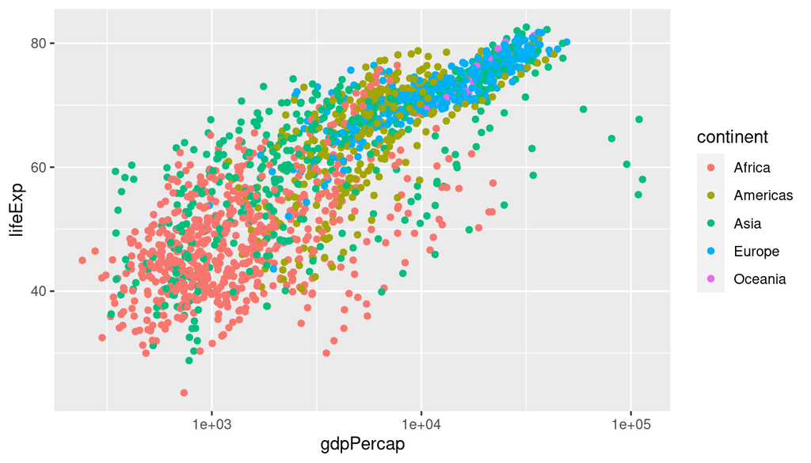

```r
# Create plot object
lifeExp_plot <- ggplot(data = gapminder,
                       mapping = aes(x = gdpPercap,
                                     y = lifeExp,
                                     color = continent)) +
  geom_point() +
  scale_x_log10()

# Draw plot
print(lifeExp_plot)
```

At this point, we want to change the colors of the points in two ways: (1) we want to make them slightly transparent because there is considerable overlap in some part of the graph; we do this by setting the `alpha` parameter in the `geom_point` call; (2) we want to use custom colors for each continent; this is done with the `scale_color_manual` function:

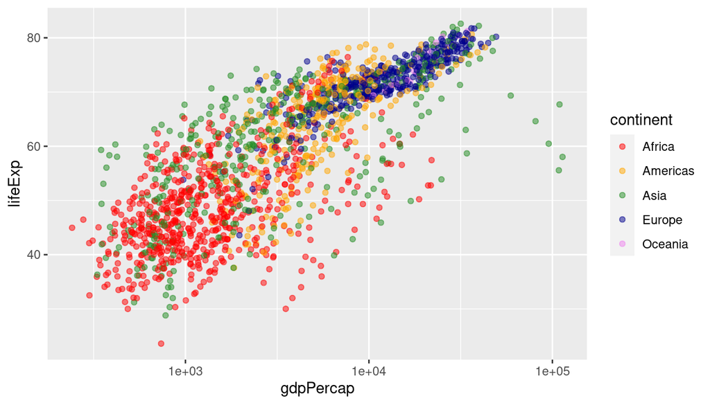

```r
# Create plot object
lifeExp_plot <- ggplot(data = gapminder,
                       mapping = aes(x = gdpPercap,
                                     y = lifeExp,
                                     color = continent)) +
  geom_point(alpha = 0.5) +
  scale_x_log10() +
  scale_color_manual(values = c("red", "orange", "forestgreen",
                                "darkblue", "violet"))

# Draw plot
print(lifeExp_plot)
```

Finally, we should make those axis labels a little nicer.

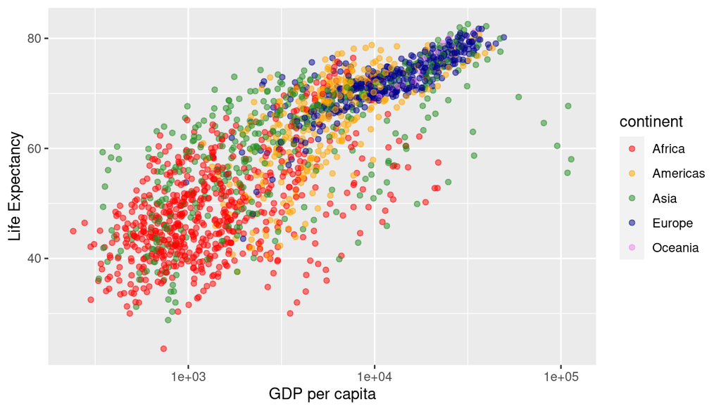

```r
# Create plot object
lifeExp_plot <- ggplot(data = gapminder,
                       mapping = aes(x = gdpPercap,
                                     y = lifeExp,
                                     color = continent)) +
  geom_point(alpha = 0.5) +
  scale_x_log10() +
  scale_color_manual(values = c("red", "orange", "forestgreen",
                                "darkblue", "violet")) +
  xlab("GDP per capita") +
  ylab("Life Expectancy")

# Draw plot
print(lifeExp_plot)
```

And if we want to save the plot to a file, we call `ggsave`, passing a filename and the plot object we want to save (the latter is optional, if we don’t indicate which plot to save, `ggsave` will save the last plot that was displayed):

```r
# Save plot to png file
ggsave(filename = "output/gdp-lifeExp-plot.png", plot = lifeExp_plot)
```

Also note that `ggsave` will guess the type of file to save from the extension. For example, if we instead wanted to save a TIF instead of a PNG, we change the extension for the `filename` argument:

```r
# Save plot to tif file
ggsave(filename = "output/gdp-lifeExp-plot.tiff", plot = lifeExp_plot)
```

Our final script for this scatterplot is then:

```r
# Plot gapminder data
# Jeff Oliver
# jcoliver@email.arizona.edu
# 2017-02-23

#install.packages("ggplot2")
library("ggplot2")

# Load data
gapminder <- read.csv(file = "data/gapminder.csv",
                      stringsAsFactors = TRUE)

# Create plot object
lifeExp_plot <- ggplot(data = gapminder,
                       mapping = aes(x = gdpPercap,
                                     y = lifeExp,
                                     color = continent)) +
  geom_point(alpha = 0.5) +
  scale_x_log10() +
  scale_color_manual(values = c("red", "orange", "forestgreen",
                                "darkblue", "violet")) +
  xlab("GDP per capita") +
  ylab("Life Expectancy")

# Draw plot
print(lifeExp_plot)

# Save plot to png file
ggsave(filename = "output/gdp-lifeExp-plot.png", plot = lifeExp_plot)
```

### Violin plot

```r
# Violin plot of GDP data
# Jeff Oliver
# jcoliver@email.arizona.edu
# 2017-02-23

rm(list = ls())

#install.packages("ggplot2")
library("ggplot2")
```

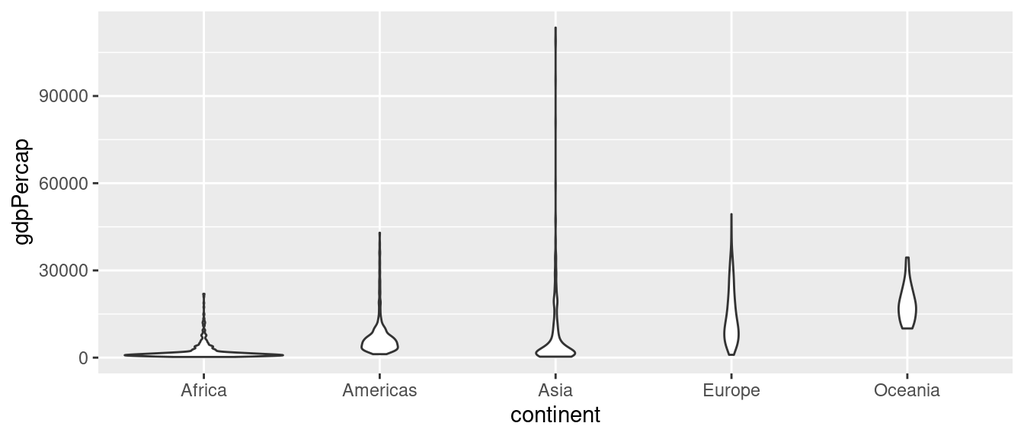

```r
# Load data
gapminder <- read.csv(file = "data/gapminder.csv",
                      stringsAsFactors = TRUE)

# Create violin plot object
gdp_plot <- ggplot(data = gapminder,
                   mapping = aes(x = continent, y = gdpPercap)) +
  geom_violin()

# Print plot
print(gdp_plot)
```

A good start, but we can see we need to clean some things up. We’ll start by changing the Y-axis to a log scale with `scale_y_log10` and adding a nicer looking axis title with `ylab`. Also, we will remove the gray background that comes with the default theme by using `theme_bw`:

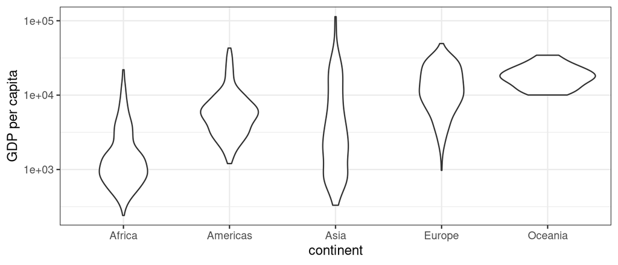

```r
# Create violin plot object
gdp_plot <- ggplot(data = gapminder,
                   mapping = aes(x = continent, y = gdpPercap)) +
  geom_violin() +
  scale_y_log10() +
  ylab("GDP per capita") +
  theme_bw()

# Print plot
print(gdp_plot)
```

One of the issues we have in the plot is not obvious just by looking at it. If we take a look at the data using `summary`, note the values in the `year` vector:

```r
summary(gapminder)
```

```
##         country          year           pop               continent      lifeExp        gdpPercap
##  Afghanistan:  12   Min.   :1952   Min.   :6.001e+04   Africa  :624   Min.   :23.60   Min.   :   241.2
##  Albania    :  12   1st Qu.:1966   1st Qu.:2.794e+06   Americas:300   1st Qu.:48.20   1st Qu.:  1202.1
##  Algeria    :  12   Median :1980   Median :7.024e+06   Asia    :396   Median :60.71   Median :  3531.8
##  Angola     :  12   Mean   :1980   Mean   :2.960e+07   Europe  :360   Mean   :59.47   Mean   :  7215.3
##  Argentina  :  12   3rd Qu.:1993   3rd Qu.:1.959e+07   Oceania : 24   3rd Qu.:70.85   3rd Qu.:  9325.5
##  Australia  :  12   Max.   :2007   Max.   :1.319e+09                  Max.   :82.60   Max.   :113523.1
##  (Other)    :1632
```

There are actually multiple years of data (1952 - 2007, at five year increments). So rather than plotting GDP for all years together, we should separate out each year of data. The `ggplot2` package makes this *very* easy with faceting. To break the data apart into separate graphs for each year, we use `facet_wrap`, passing `year` as the column in the `gapminder` data we want to use for each graph:

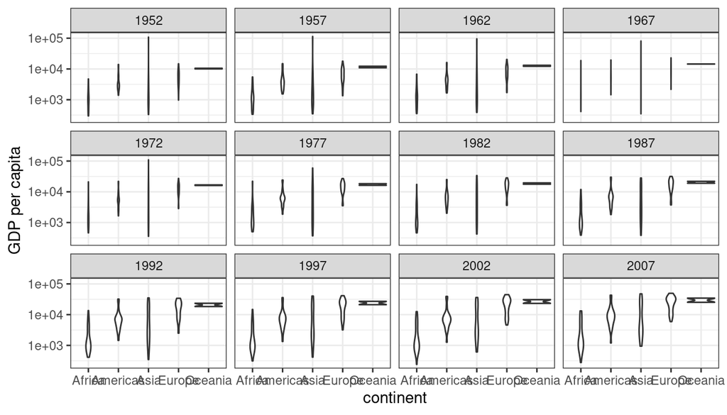

```r
# Create violin plot object
gdp_plot <- ggplot(data = gapminder,
                   mapping = aes(x = continent, y = gdpPercap)) +
  geom_violin() +
  scale_y_log10() +
  ylab("GDP per capita") +
  theme_bw() +
  facet_wrap(~ year)

# Print plot
print(gdp_plot)
```

One of the first things you might notice is that the X-axis is way to crowded now. Instead of using text to indicate each continent, we could instead use a separate color to indicate each continent, like we did in the scatterplot. We’ll use `scale_fill_manual` for this purpose, and use the `theme` function to indicate that we do not want any x-axis text or an x-axis title.

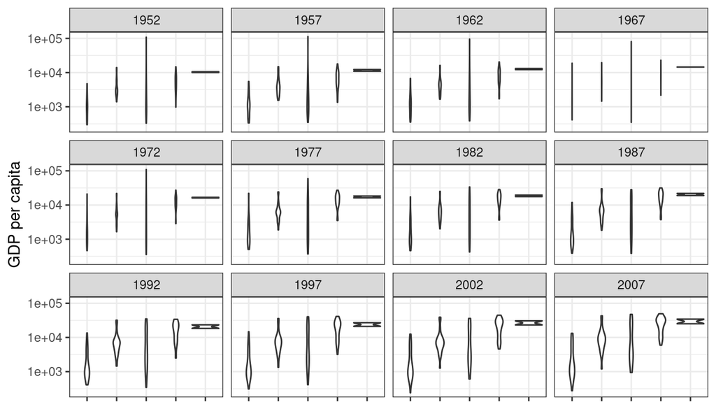

```r
# Create violin plot object
gdp_plot <- ggplot(data = gapminder,
                   mapping = aes(x = continent, y = gdpPercap)) +
  geom_violin() +
  scale_y_log10() +
  ylab("GDP per capita") +
  theme_bw() +
  facet_wrap(~ year) +
  scale_fill_manual(values = c("red", "orange", "forestgreen",
                               "darkblue", "violet")) +
  theme(axis.text.x = element_blank(),
        axis.title.x = element_blank())

# Print plot
print(gdp_plot)
```

Okay, the x-axis is cleaned up, but where are the colors? If we look at our code, note that we said what colors we wanted, but not what they corresponded to. We need to explicitly tell ggplot that we want to fill the shapes by continent; this happens in the very first `ggplot` call, by passing an additional argument, `fill` to the `aes` function:

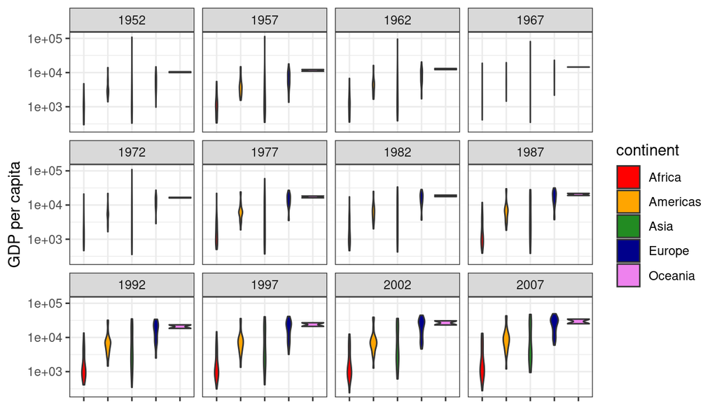

```r
# Create violin plot object
gdp_plot <- ggplot(data = gapminder,
                   mapping = aes(x = continent,
                                 y = gdpPercap,
                                 fill = continent)) +
  geom_violin() +
  scale_y_log10() +
  ylab("GDP per capita") +
  theme_bw() +
  facet_wrap(~ year) +
  scale_fill_manual(values = c("red", "orange", "forestgreen",
                               "darkblue", "violet")) +
  theme(axis.text.x = element_blank(),
        axis.title.x = element_blank())

# Print plot
print(gdp_plot)
```

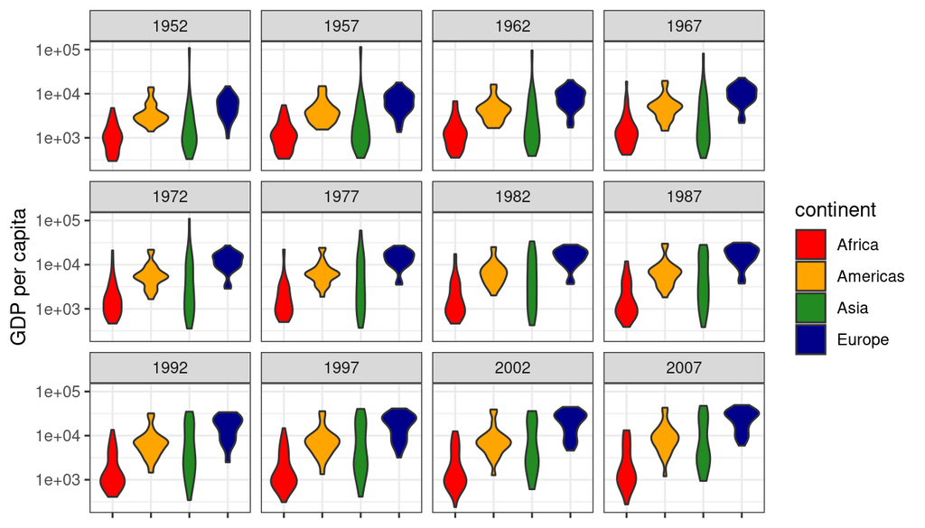

```r
# Load data
gapminder <- read.csv(file = "data/gapminder.csv",
                      stringsAsFactors = TRUE)

# Create violin plot object, excluding Oceania countries
gdp_plot <- ggplot(data = gapminder[gapminder$continent != "Oceania", ],
                   mapping = aes(x = continent, y = gdpPercap, fill = continent)) +
  geom_violin() +
  scale_y_log10() +
  ylab("GDP per capita") +
  theme_bw() +
  facet_wrap(~ year) +
  scale_fill_manual(values = c("red", "orange", "forestgreen", "darkblue")) +
  theme(axis.text.x = element_blank(),
        axis.title.x = element_blank())

# Print plot
print(gdp_plot)
```

Success!

Our final script for this violin plot is then:

```r
# Violin plot of GDP data
# Jeff Oliver
# jcoliver@email.arizona.edu
# 2017-02-23

rm(list = ls())

#install.packages("ggplot2")
library("ggplot2")

# Load data
gapminder <- read.csv(file = "data/gapminder.csv",
                      stringsAsFactors = TRUE)

# Create violin plot object, excluding Oceania countries
gdp_plot <- ggplot(data = gapminder[gapminder$continent != "Oceania", ],
                   mapping = aes(x = continent, y = gdpPercap, fill = continent)) +
  geom_violin() +
  scale_y_log10() +
  ylab("GDP per capita") +
  theme_bw() +
  facet_wrap(~ year) +
  scale_fill_manual(values = c("red", "orange", "forestgreen", "darkblue")) +
  theme(axis.text.x = element_blank(),
        axis.title.x = element_blank())

# Print plot
print(gdp_plot)
```

## Additional resources

- Official [ggplot documentation](https://ggplot2.tidyverse.org/)
- A handy [cheatsheet for ggplot](https://github.com/rstudio/cheatsheets/blob/main/data-visualization.pdf)
- A [PDF version](https://jcoliver.github.io/learn-r/004-intro-ggplot.pdf) of this lesson

Back to learn-r main page

Questions? e-mail me at jcoliver@arizona.edu.